```python
%matplotlib inline
%load_ext blackcellmagic
```

# Assignment - Simple Routing Problem

You are given a directed graph between spatial points (fixes -- i.e. named positions with longitude and latitude) in US airspace. Your task is to find the shortest path between **KSFO** and **KJFK** fixes taking into consideration weather activity.

```python
! head edges.json
```

```
[
  [
    "ABQ",
    "ADDVL"
  ],
  [
    "ABQ",
    "AHAMU"
  ],
  [
```

```python
! head fixes.json
```

```
{
  "KSFO": {
    "latitude": 37.618805555555554,
    "longitude": -122.37541666666667
  },
  "KSFO:RW01L": {
    "latitude": 37.60952777777778,
    "longitude": -122.38189722222222
  },
  "KSFO:RW10R": {
```

```python
import json
fixes = json.load(open('fixes.json'))
edges = json.load(open('edges.json'))
print(f"Loaded {len(edges)} edges and {len(fixes)} fixes.")
```

```
Loaded 116108 edges and 1103 fixes.
```

```python
import matplotlib.pyplot as plt
import matplotlib.image

weather_matrix = matplotlib.image.imread('weather.png')
weather_matrix.shape
```

```
(1280, 1792, 4)
```

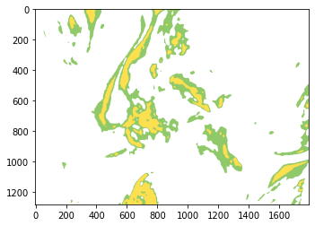

```python
plt.imshow(weather_matrix)
```

```python
weather_coordinates = json.load(open('weather.json'))
weather_coordinates
```

```
{'top_left': {'latitude': 55.78, 'longitude': -135.0},
 'bottom_right': {'latitude': 21.94, 'longitude': -67.5}}
```

```python
m = folium.Map(location=[40, -98], zoom_start=4)
folium.Marker(
    (
        weather_coordinates["bottom_right"]["latitude"],
        weather_coordinates["bottom_right"]["longitude"],
    ),
    tooltip="bottom-right",
).add_to(m)
folium.Marker(
    (
        weather_coordinates["top_left"]["latitude"],
        weather_coordinates["top_left"]["longitude"],
    ),
    tooltip="top-left",
)
folium.raster_layers.ImageOverlay(
    weather_matrix,
    pixelated=True,
    mercator_project=True,
    bounds=[
        [
            weather_coordinates["bottom_right"]["latitude"],
            weather_coordinates["top_left"]["longitude"],
        ],
        [
            weather_coordinates["top_left"]["latitude"],
            weather_coordinates["bottom_right"]["longitude"],
        ],
    ],
).add_to(m)

r = 20
for i in range(1,r):
    folium.Marker(
        (
            weather_coordinates["top_left"]["latitude"]/r*i+weather_coordinates["bottom_right"]["latitude"]/r*(r-i),
            weather_coordinates["top_left"]["longitude"]/r*i+weather_coordinates["bottom_right"]["longitude"]/r*(r-i),
        ),
        tooltip="top-left",
    ).add_to(m)

m
```

Make this Notebook Trusted to load map: File -> Trust Notebook

[interactive chart not shown]

# Solution

## Install packages

```python
import sys

!{sys.executable} -m pip install tqdm
!{sys.executable} -m pip install pqdm

!{sys.executable} -m pip install ipywidgets
!{sys.executable} -m pip install joblib
!{sys.executable} -m pip install scipy
!{sys.executable} -m pip install geopy
!{sys.executable} -m pip install networkx
!{sys.executable} -m pip install geopandas
!{sys.executable} -m pip install rasterio
```

## Define interpolate cells

I use a function that always progress including nearest neighbours, never purely diagonaly.

ex.:

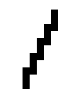

```python
import math
def interpolate_pixels_along_line(x0, y0, x1, y1):
    """Uses Xiaolin Wu's line algorithm to interpolate all of the pixels along a
    straight line, given two points (x0, y0) and (x1, y1)

    Wikipedia article containing pseudo code that function was based off of:
        http://en.wikipedia.org/wiki/Xiaolin_Wu's_line_algorithm
    """
    pixels = []
    steep = abs(y1 - y0) > abs(x1 - x0)

    # Ensure that the path to be interpolated is shallow and from left to right
    if steep:
        t = x0
        x0 = y0
        y0 = t

        t = x1
        x1 = y1
        y1 = t

    if x0 > x1:
        t = x0
        x0 = x1
        x1 = t

        t = y0
        y0 = y1
        y1 = t

    dx = x1 - x0
    dy = y1 - y0
    gradient = dy / dx  # slope

    # Get the first given coordinate and add it to the return list
    x_end = round(x0)
    y_end = y0 + (gradient * (x_end - x0))
    xpxl0 = x_end
    ypxl0 = round(y_end)
    if steep:
        pixels.extend([(ypxl0, xpxl0), (ypxl0 + 1, xpxl0)])
    else:
        pixels.extend([(xpxl0, ypxl0), (xpxl0, ypxl0 + 1)])

    interpolated_y = y_end + gradient

    # Get the second given coordinate to give the main loop a range
    x_end = round(x1)
    y_end = y1 + (gradient * (x_end - x1))
    xpxl1 = x_end
    ypxl1 = round(y_end)

    # Loop between the first x coordinate and the second x coordinate, interpolating the y coordinates

    for x in range(xpxl0 + 1, xpxl1):
        if steep:
            pixels.extend([(math.floor(interpolated_y), x), (math.floor(interpolated_y) + 1, x)])

        else:
            pixels.extend([(x, math.floor(interpolated_y)), (x, math.floor(interpolated_y) + 1)])

        interpolated_y += gradient

    # Add the second given coordinate to the given list
    if steep:
        pixels.extend([(ypxl1, xpxl1), (ypxl1 + 1, xpxl1)])
    else:
        pixels.extend([(xpxl1, ypxl1), (xpxl1, ypxl1 + 1)])

    return pixels



import math

def interpolate_pixels_along_line2(x0, y0, x1, y1):
    """Uses Xiaolin Wu's line algorithm to interpolate all of the pixels along a
    straight line, given two points (x0, y0) and (x1, y1)

    Wikipedia article containing pseudo code that function was based off of:
        http://en.wikipedia.org/wiki/Xiaolin_Wu's_line_algorithm
    """
    import numpy as np
    steep = abs(y1 - y0) > abs(x1 - x0)

    # Ensure that the path to be interpolated is shallow and from left to right
    if steep:
        t = x0
        x0 = y0
        y0 = t

        t = x1
        x1 = y1
        y1 = t

    if x0 > x1:
        t = x0
        x0 = x1
        x1 = t

        t = y0
        y0 = y1
        y1 = t

    dx = x1 - x0
    dy = y1 - y0
    gradient = dy / dx  # slope

    # Get the first given coordinate and add it to the return list
    x_end = round(x0)
    y_end = y0 + (gradient * (x_end - x0))
    xpxl0 = x_end
    ypxl0 = round(y_end)

    interpolated_y = y_end + gradient

    # Get the second given coordinate to give the main loop a range
    x_end = round(x1)
    y_end = y1 + (gradient * (x_end - x1))
    xpxl1 = x_end
    ypxl1 = round(y_end)
    rng = range(xpxl0 + 1, xpxl1)

    pixels = np.ndarray((len(rng)*2+4,2),'int')
    if steep:
        pixels[[0,1]] = [[ypxl0, xpxl0], [ypxl0 + 1, xpxl0]]
    else:
        pixels[[0,1]] = [[xpxl0, ypxl0], [xpxl0, ypxl0 + 1]]

    # Loop between the first x coordinate and the second x coordinate, interpolating the y coordinates
    i = 0
    for x in rng:
        i+=2
        if steep:
            pixels[[i,i+1]] = [[math.floor(interpolated_y), x], [math.floor(interpolated_y) + 1, x]]

        else:
            pixels[[i,i+1]] = [[x, math.floor(interpolated_y)], [x, math.floor(interpolated_y) + 1]]

        interpolated_y += gradient

    i+=2
    # Add the second given coordinate to the given list
    if steep:
        pixels[[i,i+1]] = [[ypxl1, xpxl1], [ypxl1 + 1, xpxl1]]
    else:
        pixels[[i,i+1]] = [[xpxl1, ypxl1], [xpxl1, ypxl1 + 1]]

    return pixels
```

```python
#test my implementation
assert((interpolate_pixels_along_line(1,1,4,3) == interpolate_pixels_along_line2(1,1,4,3)).all())
assert((interpolate_pixels_along_line(1,1,3,10) == interpolate_pixels_along_line2(1,1,3,10)).all())

interpolate_pixels_along_line2(1,1,4,3).transpose()[0]
```

```
array([1, 1, 2, 2, 3, 3, 4, 4])
```

## Define transformer for weather rester

y == row == latitude x == col == longitude

```python
import numpy as np
import rasterio
from rasterio import transform, crs, warp
#print(crs.CRS.from_epsg(3395))

transformer = rasterio.transform.from_bounds(
    west = weather_coordinates['top_left']['longitude'],
    south = weather_coordinates['bottom_right']['latitude'],
    east = weather_coordinates['bottom_right']['longitude'],
    north = weather_coordinates['top_left']['latitude'],
    width = weather_matrix.shape[1],
    height = weather_matrix.shape[0])
# assuming https://epsg.io/3395
#weather_rio = rasterio.open('weather.png', 'r', crs=crs.CRS.from_epsg(3395), transform=transformer)

print(rasterio.transform.xy(transformer, 0,0, offset='ul'))
print(weather_coordinates['top_left'])
print(rasterio.transform.xy(transformer, weather_matrix.shape[0],weather_matrix.shape[1], offset='ul'))
print(weather_coordinates['bottom_right'])

rasterio.transform.rowcol(transformer, weather_coordinates['bottom_right']['longitude'], weather_coordinates['bottom_right']['latitude'])

(tx,ty) = (weather_coordinates['bottom_right']['longitude'], weather_coordinates['bottom_right']['latitude'])

rasterio.transform.rowcol(transformer, tx,ty)[1] - rasterio.transform.rowcol(transformer, tx+1,ty+1)[1]

print(np.subtract(rasterio.transform.rowcol(transformer, tx-20,ty-20),rasterio.transform.rowcol(transformer, tx-20-1,ty-20+1)))
print(np.subtract(rasterio.transform.rowcol(transformer, 1.1,0.1),rasterio.transform.rowcol(transformer, 1.1-1,0.1+1)))
```

```
(-135.0, 55.78)
{'latitude': 55.78, 'longitude': -135.0}
(-67.5, 21.939999999999998)
{'latitude': 21.94, 'longitude': -67.5}
[38 27]
[38 27]
```

## Create a version of weather map with values 0,1,2

```python
#print (weather_matrix[82,370]) #yellow [0.9882353 , 0.8392157 , 0.07843138, 0.7490196 ]
#print (weather_matrix[561,652]) #green [0.41960785, 0.7176471 , 0.21960784, 0.7490196 ]
#print (weather_matrix[0,0]) #trans [1., 1., 1., 0.]

import numpy
weather_weights = numpy.zeros(weather_matrix.shape[0:2])

for y in range(weather_matrix.shape[0]-1):
    for x in range(weather_matrix.shape[1]-1):
        if(weather_matrix[y,x,3] > 0.0):
            if(weather_matrix[y,x,0] > 0.5):
                weather_weights[y,x] = 2
            else:
                weather_weights[y,x] = 1

#Test cases
assert(weather_weights[82,370] == 2.0)
assert(weather_weights[561,652] == 1.0)
assert(weather_weights[1,2] == 0.0)
```

## Define functions for weights

```python
from geopy import distance

def getGeoWeight(a,b):
    return distance.distance((a['latitude'], a['longitude']), (b['latitude'], b['longitude'])).km

def getWeatherWeight(a,b):
    (y0, x0) = rasterio.transform.rowcol(transformer, a['longitude'], a['latitude'])
    (y1, x1) = rasterio.transform.rowcol(transformer, b['longitude'], b['latitude'])
    if(y0==y1 and x0==x1): ## there are cases with distance closer than one pixel on the weather image.
        return weather_weights[y0,x0];
    else:
        indx_xy = interpolate_pixels_along_line2(x0,y0,x1,y1).transpose()
        x = indx_xy[0] # [i[0] for i in indx_tupple_list]
        y = indx_xy[1] # [i[1] for i in indx_tupple_list]
        try:
        # sum up all and normalize in respect to pixel_path_lenght/num_of_pixels_selected
            return sum(weather_weights[y,x]) / len(x) * getGeoWeight(a,b) ## math.sqrt((y1-y0)**2 + (x1-x0)**2)
        except:
            print(type(y))
            print(type(x))

            print(weather_weights[y,x])
```

### Define aggregation function for weight

```python
def getRawWeatherWeightsOnly():
    from tqdm.notebook import tqdm as tqdm
    return {(e[0],e[1]) : getWeatherWeight(fixes[e[0]], fixes[e[1]]) for e in tqdm(edges)}

def getRawDistanceWeighthOnly():
    from tqdm.notebook import tqdm as tqdm
    return {(e[0],e[1]) :getGeoWeight(fixes[e[0]], fixes[e[1]]) for e in tqdm(edges)}
```

### Get edges

Get weather unweighted weights only for purpose of speed because this can be read once.

```python
edges_weather_weights = getRawWeatherWeightsOnly()
```

Get distance weights

```python
edges_distance_weights = getRawDistanceWeighthOnly()
```

```python
def computeWeight(dist_val, weather_val, ratio):
    return dist_val + weather_val * ratio

def getEdgeWeightsCombined(ratio, edges_distance_weights, edges_weather_weights):
    return [(edwkey[0],
            edwkey[1],
            computeWeight(edges_distance_weights[edwkey], edges_weather_weights[edwkey], ratio)) for edwkey in edges_distance_weights]
```

Get edges for graph

```python
g_edges = getEdgeWeightsCombined(10.0, edges_distance_weights, edges_weather_weights)
# check
[e for e in g_edges if e[0] == 'KSFO']
```

```
[('KSFO', 'KSFO:RW28R', 1.6235742714584342),
 ('KSFO', 'KSFO:RW01L', 1.1780200983097666),
 ('KSFO', 'KSFO:RW10L', 1.932224596355162),
 ('KSFO', 'KSFO:RW28L', 1.6087763442569654),
 ('KSFO', 'KSFO:RW10R', 1.768874301219021),
 ('KSFO', 'KSFO:RW01R', 1.302078369537075),
 ('KSFO', 'KSFO:RW19L', 1.1980002549621913),
 ('KSFO', 'KSFO:RW19R', 0.9517470376017824)]
```

## Create a directional graph

```python
def CreateGraph(g_edges):
    import networkx as nx
    graph = nx.DiGraph()
    graph.add_weighted_edges_from(g_edges)
    #graph.number_of_edges()
    return graph

graph = CreateGraph(g_edges)
```

```python
#check
import networkx as nx
nx.dijkstra_path(graph, 'KSFO', 'KJFK')
```

```
['KSFO',
 'KSFO:RW28L',
 'ORYAN',
 'SAHEY',
 'MAAYS',
 'MCOVY',
 'SUSEY',
 'VNY',
 'CUDOR',
 'PERRO',
 'FANNY',
 'WNSTR',
 'TIYUR',
 'PLESS',
 'AUGUS',
 'CAGED',
 'JFK',
 'KJFK']
```

# The Final step - do it, draw it

## Do it (get the path)

### Define helper functions

```python
def getShortestPathEdgesWithWeights(shortest_path):
    shortest_path_edges = list(zip(shortest_path[:-1],shortest_path[1:]))
    shortest_path_edges_with_weights = [
        {'from' : {
             'name': e[0],
             'location' : fixes[e[0]]
            },
         'to' : {
             'name': e[1],
             'location' : fixes[e[1]]
         },
         'weight' : [f[2] for f in g_edges if e[0] == f[0] and e[1] == f[1]][0]
        } for e in shortest_path_edges]

    return shortest_path_edges_with_weights

# work in progress. To be used for visualisation
def getWeightsNormalizationFactor(shortest_path_edges_with_weights):
    weights_of_path = [e['weight'] for e in shortest_path_edges_with_weights]
    (min_weights_of_path, max_weights_of_path) = (min(weights_of_path), max(weights_of_path))
    weights_normalization_factor = 1/((max_weights_of_path - min_weights_of_path) / min_weights_of_path)
    return weights_normalization_factor
```

### Get structures used for drawing on a map.

```python
shortest_path = nx.dijkstra_path(graph, 'KSFO', 'KJFK')

shortest_path_edges_with_weights = getShortestPathEdgesWithWeights(shortest_path)
weights_normalization_factor = getWeightsNormalizationFactor(shortest_path_edges_with_weights)

#check
print('first shortest path structure: \n',shortest_path_edges_with_weights[0])
print()
print('w norm factor: ', weights_normalization_factor)
```

```
first shortest path structure:
 {'from': {'name': 'KSFO', 'location': {'latitude': 37.618805555555554, 'longitude': -122.37541666666667}}, 'to': {'name': 'KSFO:RW28L', 'location': {'latitude': 37.612097222222225, 'longitude': -122.35926388888889}}, 'weight': 1.6087763442569654}

w norm factor:  0.0012208391378259861
```

### define map creation functions

```python
def getMap():
    m = folium.Map(location=[40, -98], zoom_start=4)
    folium.raster_layers.ImageOverlay(
        weather_matrix,
        pixelated=True,
        mercator_project=True,
        bounds=[
            [
                weather_coordinates["bottom_right"]["latitude"],
                weather_coordinates["top_left"]["longitude"],
            ],
            [
                weather_coordinates["top_left"]["latitude"],
                weather_coordinates["bottom_right"]["longitude"],
            ],
        ],
    ).add_to(m)

    return m

def addMarkers(m, shortest_path_edges_with_weights, weights_normalization_factor):
    import numpy as np
    for e in shortest_path_edges_with_weights:
        folium.PolyLine(
                [
                    (e['from']['location']['latitude'], e['from']['location']['longitude']),
                    (e['to']['location']['latitude'], e['to']['location']['longitude']),
                ],
                weight= 2, #1 + (2 * e['weight'] * weights_normalization_factor)**3
            ).add_to(m)

    for e in [shortest_path_edges_with_weights[0]]:
      folium.Marker(
                    (e['from']['location']['latitude'], e['from']['location']['longitude']),
           popup = e['from']['name'], tooltip = e['from']['name']
            ).add_to(m)

    for e in shortest_path_edges_with_weights:
        folium.Marker(location=(e['to']['location']['latitude'], e['to']['location']['longitude']),
                      popup = e['to']['name'], tooltip =e['to']['name']
            ).add_to(m)


    for ei in range(0, len(shortest_path_edges_with_weights)-1):
        e = shortest_path_edges_with_weights[ei]
    #    edges_neighbours = [x[1] for x in edges if x[0] == e['from']['name']]

    #    for fix in [fixes[x] for x in edges_neighbours]:

    #        folium.Marker(location=(fix['latitude'],fix['longitude'])
    #        ).add_to(m)


        for fi in range(ei+1, len(shortest_path_edges_with_weights)):
            f = shortest_path_edges_with_weights[fi]
            #if exist an edge that skips the current hop, draw it red.
            if edges.count([e['from']['name'],f['to']['name']]):
                folium.PolyLine(
                [
                    (e['from']['location']['latitude'], e['from']['location']['longitude']),
                    (f['to']['location']['latitude'], f['to']['location']['longitude']),
                ],
                color = "red",
                weight= 1, #1 + (2 * e['weight'] * weights_normalization_factor)**3
            ).add_to(m)
```

### Draw it

```python
m = getMap()
addMarkers(m, shortest_path_edges_with_weights, weights_normalization_factor)

m
```

Make this Notebook Trusted to load map: File -> Trust Notebook

[interactive chart not shown]

# Interactive

```python
from __future__ import print_function
from ipywidgets import interact, interactive, fixed, interact_manual
import ipywidgets as widgets
```

```python
@interact(frm=sorted(fixes.keys()),to=sorted(fixes.keys()), ratio=(0.,5.,0.01))
def A(frm='KSFO',to='KJFK', ratio = 0.0):
    try:
        graph = CreateGraph(getEdgeWeightsCombined(ratio, edges_distance_weights, edges_weather_weights))
        shortest_path = nx.dijkstra_path(graph, frm, to)

        shortest_path_edges_with_weights = getShortestPathEdgesWithWeights(shortest_path)
        weights_normalization_factor = getWeightsNormalizationFactor(shortest_path_edges_with_weights)
        m = getMap()
        addMarkers(m, shortest_path_edges_with_weights, weights_normalization_factor)
        print(shortest_path)
        print(ratio)
        return m
    except: # in case there is no path.
        return getMap()
```

```
interactive(children=(Dropdown(description='frm', index=602, options=('ABQ', 'ABR', 'ACO', 'ADDVL', 'AECIA', '…
```

# Ending Notes

1. It makes sense to add artifitial fixes all over the map to allow the graph engine to change direction of travel between real fixes.
2. I tried to introduce Mercator projection where translating geo locations to pixels but I, at this point didn't find a working solution. I am aware that the weather image is more stretched as we approach north, hence pixel-wise distances should be bigger when reading data there. It is not the case, thankfully, it is not significant for USA. At least I was able to normalize the weather readings in line to geo-physical distance, no matter how many pixels where actually selected on that straight line.